# Sesgo

## Para escoger el numero de PCAs

```r
stdev9= PCApep9$sdev
pr_var9 = stdev9^2
pr_var9[1:15]
```

```
##  [1] 4.87936616 3.61442998 1.74471431 1.43619020 0.95505311 0.81873844
##  [7] 0.44773371 0.37168076 0.25800651 0.15938950 0.12176299 0.10114216
## [13] 0.05526852 0.02650797 0.01001570
```

```r
prop_varex9 =pr_var9/sum(pr_var9)
prop_varex9[1:15]
```

```
##  [1] 0.3252910773 0.2409619984 0.1163142871 0.0957460130 0.0636702071
##  [6] 0.0545825623 0.0298489139 0.0247787174 0.0172004342 0.0106259667
## [11] 0.0081175326 0.0067428105 0.0036845683 0.0017671982 0.0006677132
```

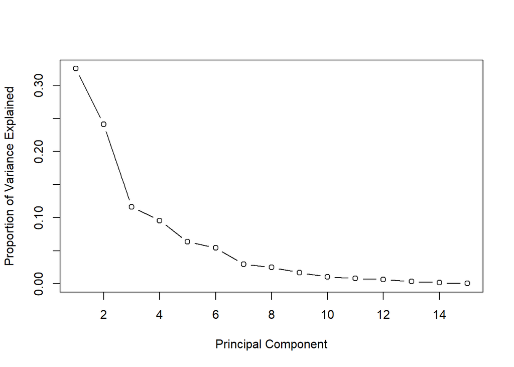

```r
plot(prop_varex9, xlab = "Principal Component",ylab = "Proportion of Variance Explained",type = "b")
```

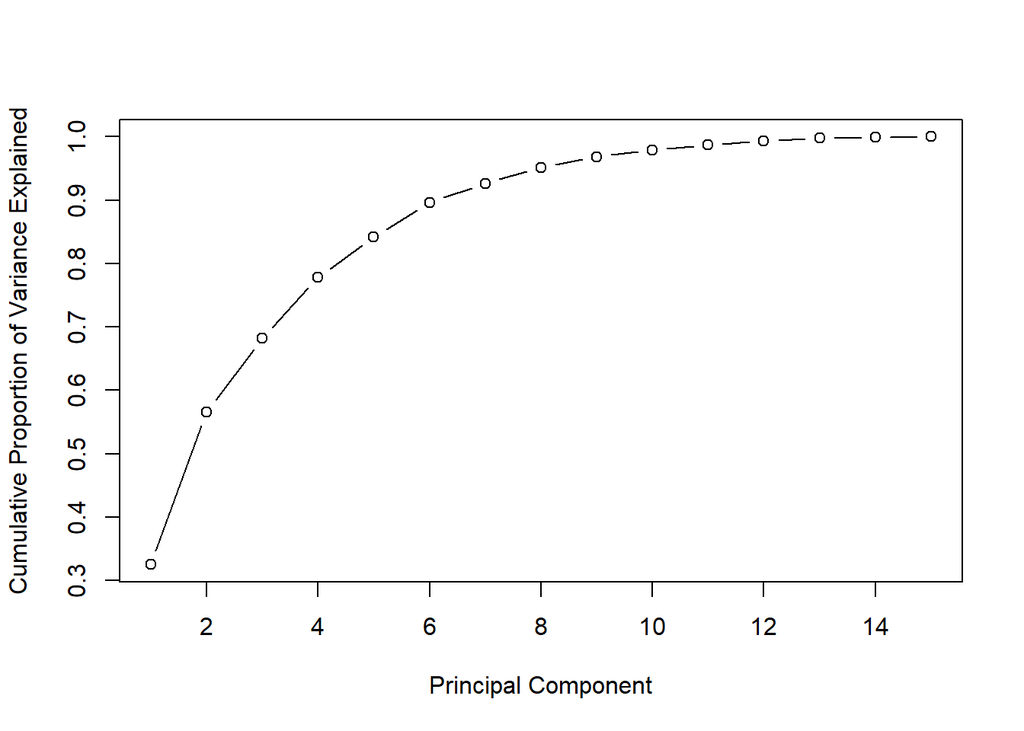

```r
plot(cumsum(prop_varex9), xlab = "Principal Component",ylab = "Cumulative Proportion of Variance Explained",type = "b")
```

## Determinar numero optimo de clusters por medio del metodo de “avarage silhouette”

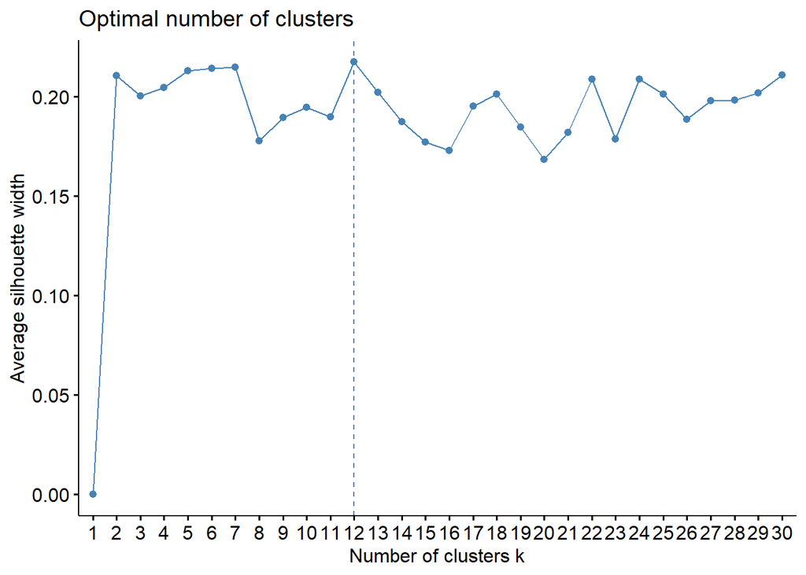

```r
fviz_nbclust(PCApep9$x[ ,1:15],kmeans,method = "silhouette", k.max = 30, iter.max=25)
```

## Graficar heatmap

## Heatmap de 9 clusters

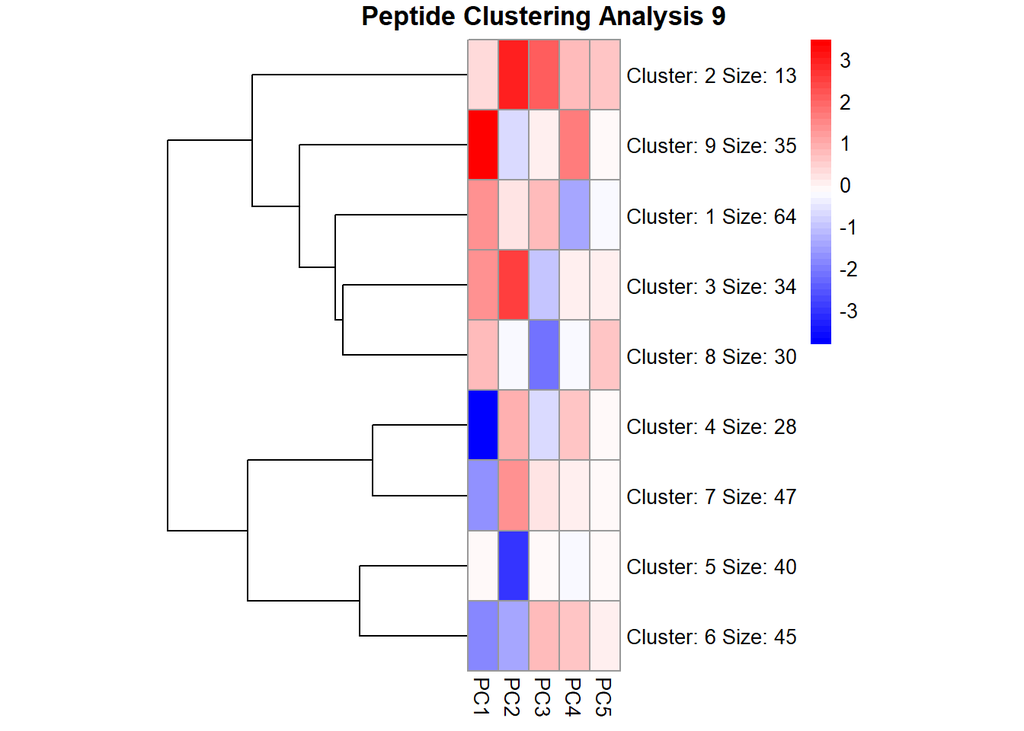

```r
cluster9pep= pheatmap(PCApep9$x[,1:5], kmeans_k = 9,cluster_cols = FALSE, treeheight_row = 150, cellwidth = 15, color = colorRampPalette(c("blue", "white", "red"))(50),main = "Peptide Clustering Analysis 9" )
```

```r
write.csv2 (cluster9pep$kmeans$cluster, file="clustermemberS9pep.csv")
```

# 10 clusters

## Leer archivo fuente, este es un excel, cambie un poco el codigo para usar lo que se

```r
Lista_calculo10 <- read_excel("C:/Users/javeb/Documents/R/TESIS/SESGADOS/CLUSTER_10.xlsx")
View(Lista_calculo10)
```

## Ahora a obtener los descriptores, verlo y guardarlos en un archivo Excel

```r
peptideDescriptors10 <- data.frame(
  Name = unlist(Lista_calculo10$Name),
  sequence = unlist(Lista_calculo10$Sequence),
  aIndex = aIndex(Lista_calculo10$Sequence),
  boman = boman(Lista_calculo10$Sequence),
  charge = charge(Lista_calculo10$Sequence, pH = 7, pKscale = "Sillero"),
  crucianiProperties = do.call(rbind.data.frame, crucianiProperties(Lista_calculo10$Sequence)),
  fasgaiVectors = do.call(rbind.data.frame, fasgaiVectors(Lista_calculo10$Sequence)),
  hydrophobicity = hydrophobicity(Lista_calculo10$Sequence, scale="Kidera"),
  pI = pI(Lista_calculo10$Sequence, pKscale="EMBOSS"),mw = mw(Lista_calculo10$Sequence))
colnames(peptideDescriptors10) <- c('Name','sequence', "aIndex", "Boman", "Charge", paste0('PP', 1:3), paste0('F', 1:6), "Hidrophobicity","pI", "MW")
view(peptideDescriptors10)
Tabla = subset(peptideDescriptors10, select = -c(sequence))
knitr::kable(Tabla, caption = "**Tabla 1.** Descriptores")
```

**Tabla 1.** Descriptores

| Name | aIndex | Boman | Charge | PP1 | PP2 | PP3 | F1 | F2 | F3 | F4 | F5 | F6 | Hidrophobicity | pI | MW |
| --- | --- | --- | --- | --- | --- | --- | --- | --- | --- | --- | --- | --- | --- | --- | --- |
| >Antiox_1 | 103.333333 | 0.5627778 | -1.0538969 | -0.3300000 | -0.4538889 | 0.0927778 | -0.1120556 | 0.0165000 | -0.3827222 | 0.8094444 | 0.1480000 | -0.2091667 | -0.0222222 | 4.258141 | 1805.0177 |
| >Antiox_2 | 37.692308 | 1.9584615 | 1.3324165 | -0.0876923 | -0.3384615 | 0.2761538 | -0.1028462 | -0.4549231 | -0.4346154 | -0.0149231 | 0.0067692 | -0.1303077 | -0.0753846 | 8.564801 | 1421.5558 |
| >Antiox_3 | 14.285714 | 3.9257143 | -4.0497356 | 0.3371429 | -0.4642857 | -0.5614286 | -0.7451429 | 0.2350000 | -0.2124286 | 0.1777143 | 0.5840000 | -1.0128571 | 0.3914286 | 3.331708 | 851.8218 |
| >Antiox_8 | 20.000000 | 2.6960000 | 0.3423275 | 0.2380000 | -0.4880000 | 0.3980000 | -0.1720000 | 0.0892000 | -0.5492000 | -0.1008000 | 0.0434000 | 0.0494000 | 0.2680000 | 7.714355 | 551.5595 |
| >Antiox_11 | 84.285714 | -0.1257143 | -0.0690935 | -0.4271429 | -0.4971429 | 0.0985714 | 0.1184286 | 0.0410000 | -0.6315714 | 0.3710000 | 0.5292857 | -0.2300000 | -0.2742857 | 5.922539 | 688.7966 |
| >Antiox_13 | 70.000000 | 3.8142857 | -2.0522868 | 0.3428571 | -0.4142857 | -0.3271429 | -0.6937143 | 0.7477143 | -0.1958571 | 0.4885714 | 0.1398571 | -0.5067143 | 0.6542857 | 3.927560 | 831.8778 |
| >Antiox_14 | 12.500000 | 3.5250000 | -3.0540422 | 0.1912500 | -0.5487500 | -0.3550000 | -0.5213750 | 0.0700000 | -0.4348750 | 0.0118750 | 0.4875000 | -0.7272500 | 0.3462500 | 3.380031 | 905.9318 |
| >Antiox_15 | 65.000000 | 0.3666667 | -1.0601915 | -0.1733333 | -0.3366667 | -0.1100000 | 0.0250000 | -0.9116667 | 0.0521667 | 0.5381667 | -0.6038333 | -0.6028333 | -0.2883333 | 3.749971 | 686.7190 |
| >Antiox_16 | 0.000000 | 4.1466667 | -0.8574335 | 0.2633333 | -0.6666667 | -0.0466667 | -0.5910000 | -0.7340000 | -0.7546667 | -0.1176667 | -0.4576667 | -0.9130000 | 0.3100000 | 5.292276 | 327.2968 |
| >Antiox_18 | 0.000000 | 5.6620000 | -0.8546791 | 0.7220000 | -0.4160000 | -0.0500000 | -0.8672000 | 0.3054000 | -0.2588000 | -0.1390000 | 0.0228000 | -0.2324000 | 0.9180000 | 5.454283 | 628.6396 |
| >Antiox_19 | 127.000000 | -0.6010000 | -0.8574335 | -0.5440000 | -0.5070000 | 0.0360000 | 0.1217000 | -0.4473000 | -0.5040000 | 0.9076000 | 0.1915000 | -0.7162000 | -0.3710000 | 5.292276 | 949.0743 |
| >Antiox_20 | 58.000000 | 1.9420000 | -1.0581935 | -0.0140000 | -0.7560000 | 0.0580000 | -0.6724000 | -0.6830000 | -0.7800000 | 0.6006000 | -0.2902000 | -0.2722000 | 0.2600000 | 3.749973 | 477.4716 |
| >Antiox_23 | 110.000000 | 2.9962500 | -3.0518889 | 0.2200000 | -0.4762500 | -0.3887500 | -0.4258750 | 0.4413750 | -0.2206250 | 0.5815000 | 0.0807500 | -0.8075000 | 0.2875000 | 3.424715 | 916.9400 |
| >Antiox_25 | 24.375000 | 2.9368750 | -1.8610398 | 0.0368750 | -0.4062500 | -0.0450000 | -0.4478125 | -0.2468125 | -0.3935000 | -0.0433750 | 0.6785000 | -0.2118125 | 0.1493750 | 4.421435 | 1799.9325 |
| >Antiox_26 | 55.714286 | 3.5728571 | 0.1437108 | 0.2028571 | -0.1128571 | 0.0614286 | -0.3172857 | -0.0554286 | 0.1348571 | 0.0510000 | 0.5651429 | 0.0808571 | 0.1900000 | 7.543349 | 900.9896 |
| >Antiox_33 | 0.000000 | 6.1757143 | 1.1449129 | 0.5371429 | -0.0328571 | 0.1128571 | -0.8104286 | 0.4600000 | 0.2075714 | -0.1510000 | -0.0302857 | 0.3044286 | 0.8714286 | 9.536916 | 959.0727 |
| >Antiox_35 | 78.000000 | -0.8440000 | 0.9404096 | -0.6180000 | -0.3220000 | 0.2160000 | -0.2940000 | 0.0024000 | -0.2030000 | 0.7898000 | -0.2876000 | 0.0868000 | -0.1120000 | 9.700016 | 520.6292 |
| >Antiox_36 | 66.666667 | -1.5200000 | -0.0591925 | -0.9333333 | -0.8400000 | 0.3700000 | 0.0696667 | -0.1923333 | -1.2246667 | 1.3343333 | -0.3296667 | -0.7820000 | -0.2333333 | 6.099982 | 217.2247 |
| >Antiox_40 | 0.000000 | 3.4300000 | -0.0659512 | 0.1300000 | -0.2000000 | 0.1300000 | -0.2395000 | -0.2256667 | -0.3216667 | -0.2906667 | -0.3861667 | 0.0555000 | 0.1133333 | 6.232445 | 736.8003 |
| >Antiox_41 | 65.000000 | -0.4950000 | -1.0560402 | -0.5633333 | -0.4050000 | -0.1500000 | 0.0468333 | -0.6111667 | -0.3663333 | 0.7368333 | 0.4315000 | -0.8098333 | -0.4050000 | 3.849974 | 618.6872 |
| >Antiox_54 | 0.000000 | 3.5614286 | 0.1411696 | 0.3600000 | -0.4457143 | 0.2571429 | -0.5458571 | -0.5974286 | -0.3405714 | 0.0950000 | -0.3295714 | -0.2041429 | 0.4157143 | 7.541473 | 792.8033 |
| >Antiox_55 | 136.000000 | -1.4660000 | -0.0591925 | -0.6380000 | -0.4880000 | 0.0820000 | -0.1552000 | -0.6068000 | -0.4196000 | 0.8744000 | 0.6312000 | -0.1560000 | -0.3560000 | 6.099982 | 485.5809 |
| >Antiox_61 | 81.666667 | 2.1266667 | -3.0497356 | 0.0066667 | -0.5716667 | -0.3916667 | -0.4201667 | 0.5503333 | -0.4898333 | 0.6648333 | 0.0040000 | -0.8713333 | 0.3850000 | 3.472814 | 646.6518 |
| >Antiox_65 | 120.000000 | -0.1476923 | 0.9407975 | -0.5430769 | -0.4000000 | 0.1638462 | 0.0543846 | -0.3433077 | -0.3396154 | 0.5430769 | -0.0232308 | -0.0020769 | -0.1192308 | 10.549999 | 1298.5662 |
| >Antiox_68 | 0.000000 | 2.3450000 | -0.0564381 | -0.0300000 | -0.0900000 | -0.1600000 | -0.4740000 | 0.0537500 | 0.1740000 | 0.0980000 | 1.0285000 | -0.3172500 | 0.1725000 | 6.408784 | 519.5981 |
| >Antiox_69 | 0.000000 | 5.4225000 | 0.1453109 | 0.3875000 | -0.2375000 | 0.0375000 | -0.6875000 | -0.0637500 | -0.1145000 | -0.0697500 | -0.2121250 | -0.0971250 | 0.6312500 | 7.550345 | 1002.0543 |
| >Antiox_70 | 0.000000 | 3.2142857 | 2.1312586 | 0.0271429 | -0.1442857 | 0.4042857 | -0.1255714 | -0.1348571 | -0.2245714 | -0.2768571 | -0.2864286 | 0.5674286 | 0.2628571 | 9.834312 | 847.9903 |
| >Antiox_74 | 97.500000 | 2.5575000 | -7.0470273 | 0.2041667 | -0.4300000 | -0.5808333 | -0.4209167 | 0.9085000 | -0.2910833 | 0.5293333 | 0.2218333 | -0.8490000 | 0.3066667 | 3.166502 | 1421.4926 |
| >Antiox_77 | 118.888889 | 1.6622222 | -2.0571945 | -0.1022222 | -0.5877778 | -0.1777778 | -0.4395556 | -0.4892222 | -0.4334444 | 0.6831111 | -0.3314444 | -0.6966667 | 0.0355556 | 3.491901 | 915.9552 |
| >Antiox_78 | 130.000000 | -0.4000000 | 0.1415675 | -0.3700000 | -0.3600000 | 0.2066667 | 0.2416667 | -0.2100000 | -0.3256667 | 0.5753333 | -0.1926667 | -0.3726667 | -0.3266667 | 7.550325 | 325.3676 |

[output cut: 180 more lines]

```r
write.csv2(peptideDescriptors10, "Descriptores10.csv")
```

## Quito primera y segunda fila y exploratorio de datos

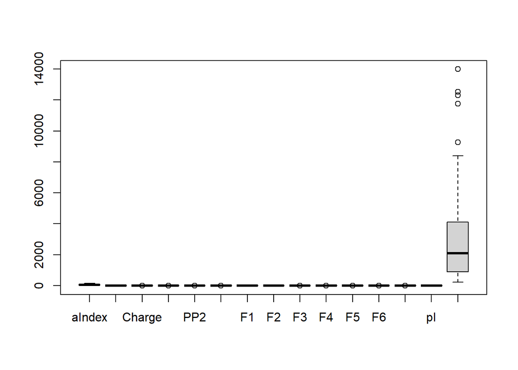

```r
datapep10= subset(peptideDescriptors10, select = -c(Name, sequence))
view(datapep10)
boxplot(datapep10)
```

```r
summary(datapep10)
```

```
##      aIndex           Boman             Charge             PP1
##  Min.   :  0.00   Min.   :-1.8280   Min.   :-7.0470   Min.   :-0.93333
##  1st Qu.: 27.99   1st Qu.: 0.7564   1st Qu.:-1.0048   1st Qu.:-0.23388
##  Median : 56.01   Median : 1.8120   Median : 0.1158   Median :-0.08792
##  Mean   : 57.71   Mean   : 1.8949   Mean   : 0.8415   Mean   :-0.08033
##  3rd Qu.: 85.19   3rd Qu.: 2.9234   3rd Qu.: 1.9438   3rd Qu.: 0.08230
##  Max.   :155.00   Max.   : 6.1757   Max.   : 9.8589   Max.   : 0.72200
##       PP2               PP3                  F1                 F2
##  Min.   :-0.8400   Min.   :-0.580833   Min.   :-0.94020   Min.   :-1.1127
##  1st Qu.:-0.4491   1st Qu.: 0.009027   1st Qu.:-0.44433   1st Qu.:-0.3869
##  Median :-0.3730   Median : 0.104479   Median :-0.22558   Median :-0.1486
##  Mean   :-0.3681   Mean   : 0.077855   Mean   :-0.27248   Mean   :-0.1191
##  3rd Qu.:-0.2944   3rd Qu.: 0.191939   3rd Qu.:-0.07388   3rd Qu.: 0.1385
##  Max.   : 0.2233   Max.   : 0.511579   Max.   : 0.28327   Max.   : 0.9085
##        F3                F4                 F5                 F6
##  Min.   :-1.2247   Min.   :-0.52275   Min.   :-0.60383   Min.   :-1.20275
##  1st Qu.:-0.4664   1st Qu.:-0.07344   1st Qu.:-0.20281   1st Qu.:-0.26527
##  Median :-0.3132   Median : 0.21200   Median :-0.04174   Median :-0.06220
##  Mean   :-0.3051   Mean   : 0.23013   Mean   : 0.04382   Mean   :-0.09457
##  3rd Qu.:-0.1717   3rd Qu.: 0.48114   3rd Qu.: 0.24276   3rd Qu.: 0.09826
##  Max.   : 0.7943   Max.   : 1.33433   Max.   : 1.11080   Max.   : 0.79947
##  Hidrophobicity           pI               MW
##  Min.   :-0.51667   Min.   : 3.167   Min.   :  217.2
##  1st Qu.:-0.05959   1st Qu.: 5.306   1st Qu.:  889.4
##  Median : 0.07900   Median : 7.092   Median : 2085.4
##  Mean   : 0.12768   Mean   : 7.244   Mean   : 2840.2
##  3rd Qu.: 0.30331   3rd Qu.: 9.291   3rd Qu.: 4107.7
##  Max.   : 0.98200   Max.   :12.802   Max.   :13992.9
```

## Normalizar y ver cambios

```r
pepscale10 = scale(datapep10)
summary(pepscale10)
```

```
##      aIndex             Boman              Charge             PP1
##  Min.   :-1.57736   Min.   :-2.41958   Min.   :-2.8900   Min.   :-3.29206
##  1st Qu.:-0.81242   1st Qu.:-0.73991   1st Qu.:-0.6764   1st Qu.:-0.59263
##  Median :-0.04658   Median :-0.05389   Median :-0.2659   Median :-0.02929
##  Mean   : 0.00000   Mean   : 0.00000   Mean   : 0.0000   Mean   : 0.00000
##  3rd Qu.: 0.75105   3rd Qu.: 0.66842   3rd Qu.: 0.4039   3rd Qu.: 0.62765
##  Max.   : 2.65889   Max.   : 2.78214   Max.   : 3.3037   Max.   : 3.09649
##       PP2               PP3                F1                F2
##  Min.   :-2.9792   Min.   :-3.4042   Min.   :-2.6817   Min.   :-2.7034
##  1st Qu.:-0.5110   1st Qu.:-0.3557   1st Qu.:-0.6902   1st Qu.:-0.7285
##  Median :-0.0308   Median : 0.1376   Median : 0.1884   Median :-0.0801
##  Mean   : 0.0000   Mean   : 0.0000   Mean   : 0.0000   Mean   : 0.0000
##  3rd Qu.: 0.4654   3rd Qu.: 0.5896   3rd Qu.: 0.7976   3rd Qu.: 0.7009
##  Max.   : 3.7342   Max.   : 2.2415   Max.   : 2.2320   Max.   : 2.7960
##        F3                 F4                 F5                F6
##  Min.   :-3.27846   Min.   :-2.05561   Min.   :-1.9985   Min.   :-3.21193
##  1st Qu.:-0.57529   1st Qu.:-0.82883   1st Qu.:-0.7610   1st Qu.:-0.49475
##  Median :-0.02891   Median :-0.04949   Median :-0.2640   Median : 0.09384
##  Mean   : 0.00000   Mean   : 0.00000   Mean   : 0.0000   Mean   : 0.00000
##  3rd Qu.: 0.47537   3rd Qu.: 0.68535   3rd Qu.: 0.6139   3rd Qu.: 0.55891
##  Max.   : 3.91940   Max.   : 3.01486   Max.   : 3.2924   Max.   : 2.59128
##  Hidrophobicity          pI                 MW
##  Min.   :-2.3413   Min.   :-1.64883   Min.   :-1.0592
##  1st Qu.:-0.6805   1st Qu.:-0.78366   1st Qu.:-0.7878
##  Median :-0.1769   Median :-0.06123   Median :-0.3048
##  Mean   : 0.0000   Mean   : 0.00000   Mean   : 0.0000
##  3rd Qu.: 0.6382   3rd Qu.: 0.82807   3rd Qu.: 0.5118
##  Max.   : 3.1043   Max.   : 2.24760   Max.   : 4.5037
```

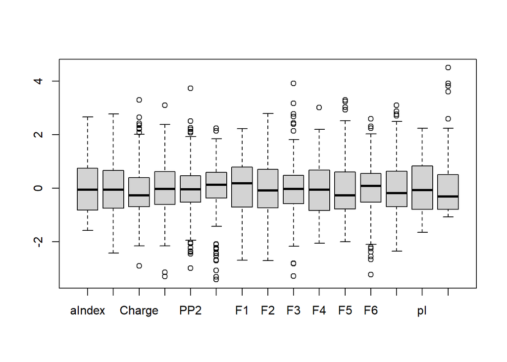

```r
boxplot(pepscale10)
```

## Calculo PCAs y obtención de archivo Excel de rotación

```r
PCApep10 = prcomp(pepscale10)
summary(PCApep10)
```

```
## Importance of components:
##                           PC1    PC2    PC3     PC4     PC5     PC6     PC7
## Standard deviation     2.0685 1.8933 1.4355 1.20841 1.01655 0.91662 0.74781
## Proportion of Variance 0.2853 0.2390 0.1374 0.09735 0.06889 0.05601 0.03728
## Cumulative Proportion  0.2853 0.5242 0.6616 0.75894 0.82783 0.88384 0.92112
##                            PC8     PC9    PC10    PC11    PC12    PC13    PC14
## Standard deviation     0.61171 0.51575 0.47337 0.36019 0.29044 0.25006 0.16749
## Proportion of Variance 0.02495 0.01773 0.01494 0.00865 0.00562 0.00417 0.00187
## Cumulative Proportion  0.94607 0.96380 0.97874 0.98739 0.99301 0.99718 0.99905
##                           PC15
## Standard deviation     0.11920
## Proportion of Variance 0.00095
## Cumulative Proportion  1.00000
```

```r
##write.csv2(PCApep10, "PCApep10.csv")##
```

## Para escoger el numero de PCAs

```r
stdev10= PCApep10$sdev
pr_var10 = stdev10^2
pr_var10[1:15]
```

```
##  [1] 4.27885354 3.58439951 2.06053245 1.46026563 1.03338392 0.84019605
##  [7] 0.55922486 0.37418407 0.26599767 0.22407664 0.12974002 0.08435500
## [13] 0.06253007 0.02805162 0.01420895
```

```r
prop_varex10 =pr_var10/sum(pr_var10)
prop_varex10[1:15]
```

```
##  [1] 0.2852569025 0.2389599671 0.1373688302 0.0973510417 0.0688922611
##  [6] 0.0560130699 0.0372816575 0.0249456048 0.0177331781 0.0149384425
## [11] 0.0086493348 0.0056236669 0.0041686715 0.0018701079 0.0009472636
```

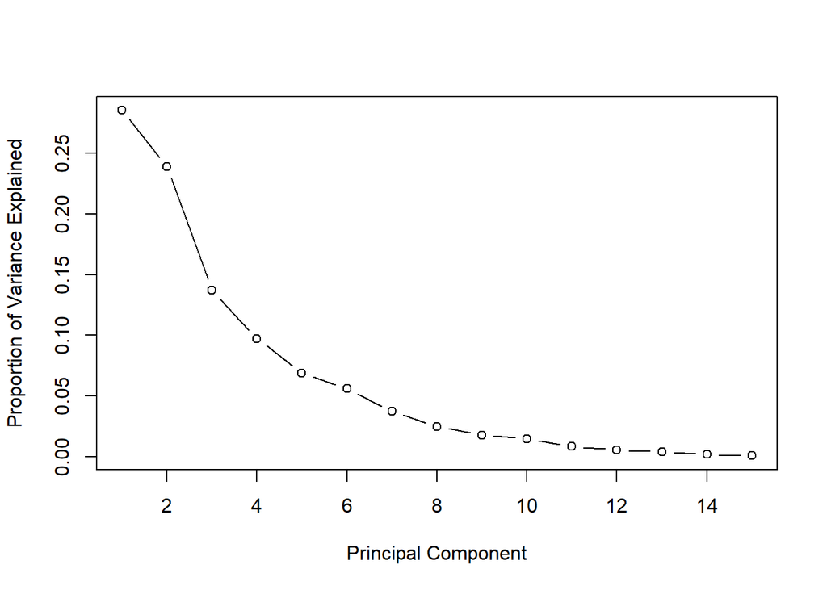

```r
plot(prop_varex10, xlab = "Principal Component",ylab = "Proportion of Variance Explained",type = "b")
```

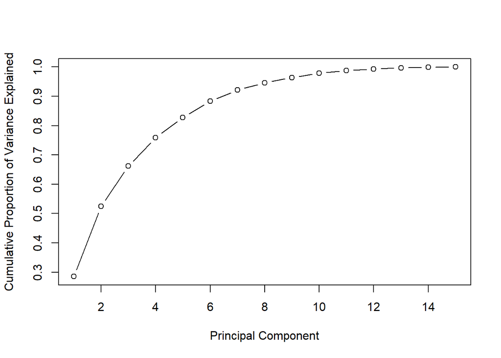

```r
plot(cumsum(prop_varex10), xlab = "Principal Component",ylab = "Cumulative Proportion of Variance Explained",type = "b")
```

## Determinar numero optimo de clusters por medio del metodo de “avarage silhouette”

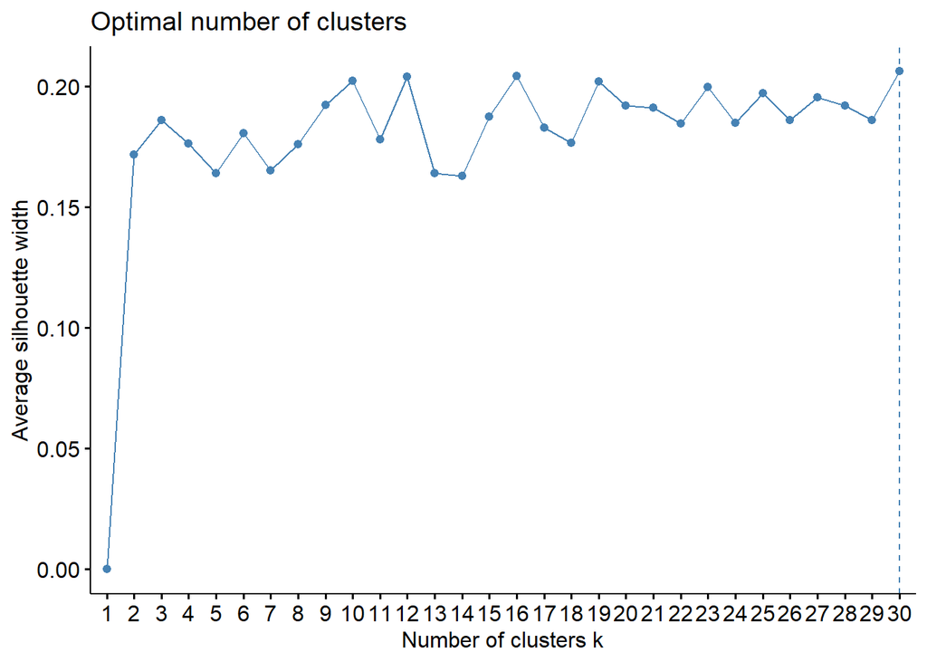

```r
fviz_nbclust(PCApep10$x[ ,1:15],kmeans,method = "silhouette", k.max = 30, iter.max=25)
```

## Graficar heatmap

## Heatmap de 10 clusters

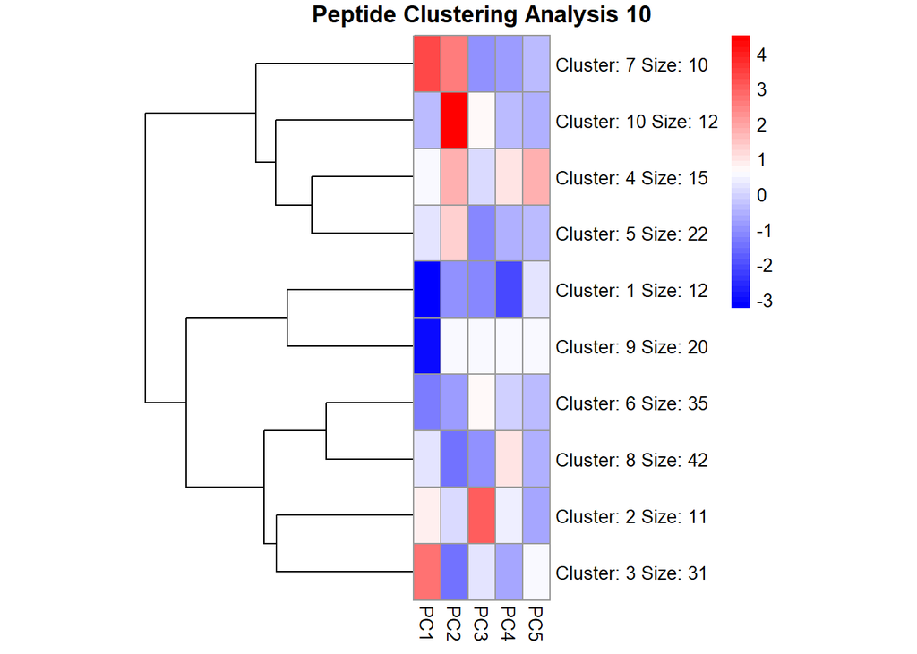

```r
cluster10pep= pheatmap(PCApep10$x[,1:5], kmeans_k = 10,cluster_cols = FALSE, treeheight_row = 150, cellwidth = 15, color = colorRampPalette(c("blue", "white", "red"))(50),main = "Peptide Clustering Analysis 10" )
```

```r
write.csv2 (cluster10pep$kmeans$cluster, file="clustermemberS10pep.csv")
```

# 11 clusters

## Leer archivo fuente, este es un excel, cambie un poco el codigo para usar lo que se

```r
Lista_calculo11 <- read_excel("C:/Users/javeb/Documents/R/TESIS/SESGADOS/CLUSTER_11.xlsx")
View(Lista_calculo11)
```

## Ahora a obtener los descriptores, verlo y guardarlos en un archivo Excel

```r
peptideDescriptors11 <- data.frame(
  Name = unlist(Lista_calculo11$Name),
  sequence = unlist(Lista_calculo11$Sequence),
  aIndex = aIndex(Lista_calculo11$Sequence),
  boman = boman(Lista_calculo11$Sequence),
  charge = charge(Lista_calculo11$Sequence, pH = 7, pKscale = "Sillero"),
  crucianiProperties = do.call(rbind.data.frame, crucianiProperties(Lista_calculo11$Sequence)),
  fasgaiVectors = do.call(rbind.data.frame, fasgaiVectors(Lista_calculo11$Sequence)),
  hydrophobicity = hydrophobicity(Lista_calculo11$Sequence, scale="Kidera"),
  pI = pI(Lista_calculo11$Sequence, pKscale="EMBOSS"),mw = mw(Lista_calculo11$Sequence))
colnames(peptideDescriptors11) <- c('Name','sequence', "aIndex", "Boman", "Charge", paste0('PP', 1:3), paste0('F', 1:6), "Hidrophobicity","pI", "MW")
view(peptideDescriptors11)
Tabla = subset(peptideDescriptors11, select = -c(sequence))
knitr::kable(Tabla, caption = "**Tabla 1.** Descriptores")
```

**Tabla 1.** Descriptores

| Name | aIndex | Boman | Charge | PP1 | PP2 | PP3 | F1 | F2 | F3 | F4 | F5 | F6 | Hidrophobicity | pI | MW |
| --- | --- | --- | --- | --- | --- | --- | --- | --- | --- | --- | --- | --- | --- | --- | --- |
| >Antiox_1 | 103.33333 | 0.5627778 | -1.0538969 | -0.3300000 | -0.4538889 | 0.0927778 | -0.1120556 | 0.0165000 | -0.3827222 | 0.8094444 | 0.1480000 | -0.2091667 | -0.0222222 | 4.258141 | 1805.0177 |
| >Antiox_2 | 37.69231 | 1.9584615 | 1.3324165 | -0.0876923 | -0.3384615 | 0.2761538 | -0.1028462 | -0.4549231 | -0.4346154 | -0.0149231 | 0.0067692 | -0.1303077 | -0.0753846 | 8.564801 | 1421.5558 |
| >Antiox_3 | 14.28571 | 3.9257143 | -4.0497356 | 0.3371429 | -0.4642857 | -0.5614286 | -0.7451429 | 0.2350000 | -0.2124286 | 0.1777143 | 0.5840000 | -1.0128571 | 0.3914286 | 3.331708 | 851.8218 |
| >Antiox_8 | 20.00000 | 2.6960000 | 0.3423275 | 0.2380000 | -0.4880000 | 0.3980000 | -0.1720000 | 0.0892000 | -0.5492000 | -0.1008000 | 0.0434000 | 0.0494000 | 0.2680000 | 7.714355 | 551.5595 |
| >Antiox_11 | 84.28571 | -0.1257143 | -0.0690935 | -0.4271429 | -0.4971429 | 0.0985714 | 0.1184286 | 0.0410000 | -0.6315714 | 0.3710000 | 0.5292857 | -0.2300000 | -0.2742857 | 5.922539 | 688.7966 |
| >Antiox_13 | 70.00000 | 3.8142857 | -2.0522868 | 0.3428571 | -0.4142857 | -0.3271429 | -0.6937143 | 0.7477143 | -0.1958571 | 0.4885714 | 0.1398571 | -0.5067143 | 0.6542857 | 3.927560 | 831.8778 |
| >Antiox_14 | 12.50000 | 3.5250000 | -3.0540422 | 0.1912500 | -0.5487500 | -0.3550000 | -0.5213750 | 0.0700000 | -0.4348750 | 0.0118750 | 0.4875000 | -0.7272500 | 0.3462500 | 3.380031 | 905.9318 |
| >Antiox_16 | 0.00000 | 4.1466667 | -0.8574335 | 0.2633333 | -0.6666667 | -0.0466667 | -0.5910000 | -0.7340000 | -0.7546667 | -0.1176667 | -0.4576667 | -0.9130000 | 0.3100000 | 5.292276 | 327.2968 |
| >Antiox_18 | 0.00000 | 5.6620000 | -0.8546791 | 0.7220000 | -0.4160000 | -0.0500000 | -0.8672000 | 0.3054000 | -0.2588000 | -0.1390000 | 0.0228000 | -0.2324000 | 0.9180000 | 5.454283 | 628.6396 |
| >Antiox_19 | 127.00000 | -0.6010000 | -0.8574335 | -0.5440000 | -0.5070000 | 0.0360000 | 0.1217000 | -0.4473000 | -0.5040000 | 0.9076000 | 0.1915000 | -0.7162000 | -0.3710000 | 5.292276 | 949.0743 |
| >Antiox_20 | 58.00000 | 1.9420000 | -1.0581935 | -0.0140000 | -0.7560000 | 0.0580000 | -0.6724000 | -0.6830000 | -0.7800000 | 0.6006000 | -0.2902000 | -0.2722000 | 0.2600000 | 3.749973 | 477.4716 |
| >Antiox_23 | 110.00000 | 2.9962500 | -3.0518889 | 0.2200000 | -0.4762500 | -0.3887500 | -0.4258750 | 0.4413750 | -0.2206250 | 0.5815000 | 0.0807500 | -0.8075000 | 0.2875000 | 3.424715 | 916.9400 |
| >Antiox_25 | 24.37500 | 2.9368750 | -1.8610398 | 0.0368750 | -0.4062500 | -0.0450000 | -0.4478125 | -0.2468125 | -0.3935000 | -0.0433750 | 0.6785000 | -0.2118125 | 0.1493750 | 4.421435 | 1799.9325 |
| >Antiox_35 | 78.00000 | -0.8440000 | 0.9404096 | -0.6180000 | -0.3220000 | 0.2160000 | -0.2940000 | 0.0024000 | -0.2030000 | 0.7898000 | -0.2876000 | 0.0868000 | -0.1120000 | 9.700016 | 520.6292 |
| >Antiox_36 | 66.66667 | -1.5200000 | -0.0591925 | -0.9333333 | -0.8400000 | 0.3700000 | 0.0696667 | -0.1923333 | -1.2246667 | 1.3343333 | -0.3296667 | -0.7820000 | -0.2333333 | 6.099982 | 217.2247 |
| >Antiox_54 | 0.00000 | 3.5614286 | 0.1411696 | 0.3600000 | -0.4457143 | 0.2571429 | -0.5458571 | -0.5974286 | -0.3405714 | 0.0950000 | -0.3295714 | -0.2041429 | 0.4157143 | 7.541473 | 792.8033 |
| >Antiox_61 | 81.66667 | 2.1266667 | -3.0497356 | 0.0066667 | -0.5716667 | -0.3916667 | -0.4201667 | 0.5503333 | -0.4898333 | 0.6648333 | 0.0040000 | -0.8713333 | 0.3850000 | 3.472814 | 646.6518 |
| >Antiox_65 | 120.00000 | -0.1476923 | 0.9407975 | -0.5430769 | -0.4000000 | 0.1638462 | 0.0543846 | -0.3433077 | -0.3396154 | 0.5430769 | -0.0232308 | -0.0020769 | -0.1192308 | 10.549999 | 1298.5662 |
| >Antiox_68 | 0.00000 | 2.3450000 | -0.0564381 | -0.0300000 | -0.0900000 | -0.1600000 | -0.4740000 | 0.0537500 | 0.1740000 | 0.0980000 | 1.0285000 | -0.3172500 | 0.1725000 | 6.408784 | 519.5981 |
| >Antiox_69 | 0.00000 | 5.4225000 | 0.1453109 | 0.3875000 | -0.2375000 | 0.0375000 | -0.6875000 | -0.0637500 | -0.1145000 | -0.0697500 | -0.2121250 | -0.0971250 | 0.6312500 | 7.550345 | 1002.0543 |
| >Antiox_73 | 118.00000 | 0.7300000 | 0.9404096 | -0.2800000 | -0.3920000 | 0.2800000 | -0.1564000 | 0.4806000 | -0.2916000 | 0.9228000 | -0.0092000 | -0.1578000 | 0.1740000 | 9.700016 | 515.6101 |
| >Antiox_74 | 97.50000 | 2.5575000 | -7.0470273 | 0.2041667 | -0.4300000 | -0.5808333 | -0.4209167 | 0.9085000 | -0.2910833 | 0.5293333 | 0.2218333 | -0.8490000 | 0.3066667 | 3.166502 | 1421.4926 |
| >Antiox_77 | 118.88889 | 1.6622222 | -2.0571945 | -0.1022222 | -0.5877778 | -0.1777778 | -0.4395556 | -0.4892222 | -0.4334444 | 0.6831111 | -0.3314444 | -0.6966667 | 0.0355556 | 3.491901 | 915.9552 |
| >Antiox_78 | 130.00000 | -0.4000000 | 0.1415675 | -0.3700000 | -0.3600000 | 0.2066667 | 0.2416667 | -0.2100000 | -0.3256667 | 0.5753333 | -0.1926667 | -0.3726667 | -0.3266667 | 7.550325 | 325.3676 |
| >Antiox_79 | 120.00000 | 2.9584615 | -3.0463801 | 0.3015385 | -0.2561538 | -0.3600000 | -0.4944615 | 0.8866154 | 0.0973846 | 0.6191538 | 0.2433077 | -0.3395385 | 0.5146154 | 3.986904 | 1614.8130 |
| >Antiox_89 | 48.75000 | 1.9200000 | -0.0591925 | -0.0437500 | -0.4462500 | -0.1062500 | -0.3921250 | -0.4780000 | -0.4186250 | 0.3017500 | 0.2491250 | -0.2401250 | 0.2787500 | 6.099982 | 854.9179 |
| >Antiox_91 | 73.12500 | 1.4893750 | -0.0602015 | -0.0943750 | -0.3856250 | 0.1056250 | -0.2090625 | -0.4280625 | -0.2146250 | 0.5300625 | 0.0503750 | -0.0173125 | 0.0512500 | 6.325263 | 1727.8913 |
| >Antiox_94 | 125.00000 | -0.4178571 | -2.0649422 | -0.5107143 | -0.5150000 | -0.1435714 | -0.5187857 | 0.0000714 | -0.4565000 | 0.5184286 | 0.4036429 | -0.1935000 | -0.2050000 | 3.550058 | 1396.6215 |
| >Antiox_95 | 75.55556 | 3.1000000 | -0.6566735 | 0.2277778 | -0.3722222 | -0.1166667 | -0.5861111 | -0.1537778 | -0.1515556 | -0.1595556 | 0.3087778 | -0.2711111 | 0.2044444 | 6.496521 | 1073.1330 |
| >Antiox_102 | 105.38462 | 0.3561538 | -2.0550412 | -0.3484615 | -0.5015385 | -0.0892308 | -0.0014615 | -0.1747692 | -0.4109231 | 0.8762308 | -0.1932308 | -0.7193077 | -0.1653846 | 3.550064 | 1290.3950 |

[output cut: 201 more lines]

```r
write.csv2(peptideDescriptors11, "Descriptores11.csv")
```

## Quito primera y segunda fila y exploratorio de datos

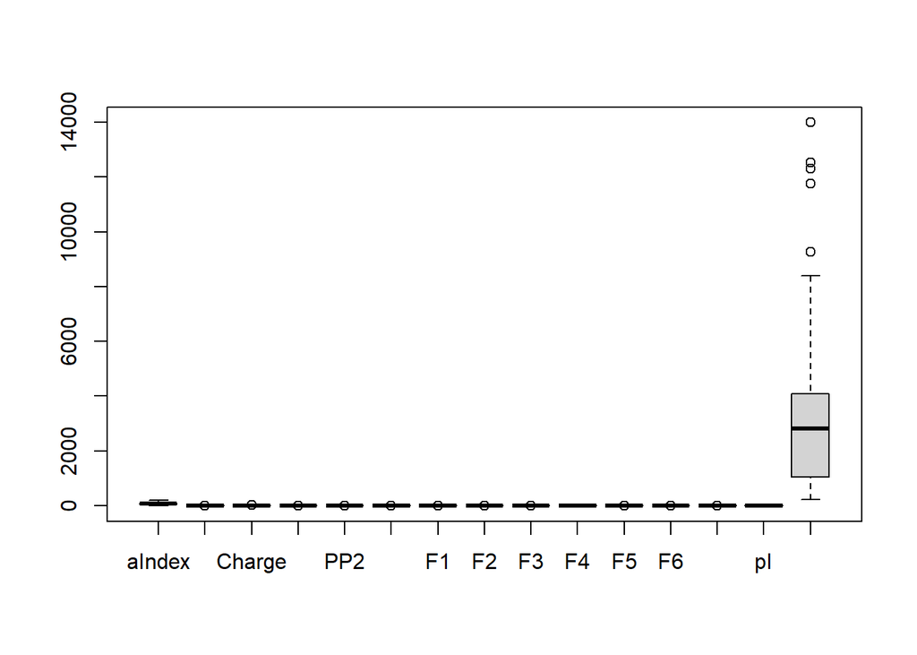

```r
datapep11= subset(peptideDescriptors11, select = -c(Name, sequence))
view(datapep11)
boxplot(datapep11)
```

```r
summary(datapep11)
```

```
##      aIndex           Boman             Charge             PP1
##  Min.   :  0.00   Min.   :-1.5200   Min.   :-7.0470   Min.   :-0.933333
##  1st Qu.: 38.32   1st Qu.: 0.4618   1st Qu.:-0.1386   1st Qu.:-0.295189
##  Median : 75.16   Median : 1.4894   Median : 0.9404   Median :-0.145636
##  Mean   : 72.41   Mean   : 1.5803   Mean   : 1.8406   Mean   :-0.131943
##  3rd Qu.:104.28   3rd Qu.: 2.4357   3rd Qu.: 4.5050   3rd Qu.:-0.004583
##  Max.   :193.33   Max.   : 5.6620   Max.   :12.9380   Max.   : 0.722000
##       PP2               PP3                 F1                 F2
##  Min.   :-0.8400   Min.   :-0.58083   Min.   :-1.35033   Min.   :-1.11275
##  1st Qu.:-0.4343   1st Qu.: 0.03894   1st Qu.:-0.42262   1st Qu.:-0.30922
##  Median :-0.3561   Median : 0.14091   Median :-0.19764   Median :-0.00876
##  Mean   :-0.3487   Mean   : 0.11291   Mean   :-0.25447   Mean   :-0.03197
##  3rd Qu.:-0.2713   3rd Qu.: 0.24677   3rd Qu.:-0.06667   3rd Qu.: 0.21541
##  Max.   : 0.2233   Max.   : 0.44857   Max.   : 0.24167   Max.   : 0.90850
##        F3                F4                 F5                  F6
##  Min.   :-1.2247   Min.   :-0.52275   Min.   :-0.475667   Min.   :-1.20275
##  1st Qu.:-0.4540   1st Qu.: 0.01073   1st Qu.:-0.179944   1st Qu.:-0.18877
##  Median :-0.2710   Median : 0.38341   Median :-0.042405   Median :-0.02751
##  Mean   :-0.2658   Mean   : 0.33484   Mean   : 0.004861   Mean   :-0.02587
##  3rd Qu.:-0.1099   3rd Qu.: 0.64720   3rd Qu.: 0.115850   3rd Qu.: 0.19099
##  Max.   : 0.7943   Max.   : 1.33433   Max.   : 1.110800   Max.   : 1.14658
##  Hidrophobicity           pI               MW
##  Min.   :-0.51667   Min.   : 3.167   Min.   :  217.2
##  1st Qu.:-0.03503   1st Qu.: 5.984   1st Qu.: 1048.1
##  Median : 0.09091   Median : 7.811   Median : 2807.6
##  Mean   : 0.12780   Mean   : 8.034   Mean   : 2971.3
##  3rd Qu.: 0.27429   3rd Qu.:10.736   3rd Qu.: 4075.4
##  Max.   : 0.98200   Max.   :13.213   Max.   :13992.9
```

## Normalizar y ver cambios

```r
pepscale11 = scale(datapep11)
summary(pepscale11)
```

```
##      aIndex            Boman              Charge             PP1
##  Min.   :-1.7640   Min.   :-2.24941   Min.   :-2.5908   Min.   :-3.3944
##  1st Qu.:-0.8305   1st Qu.:-0.81152   1st Qu.:-0.5770   1st Qu.:-0.6915
##  Median : 0.0670   Median :-0.06598   Median :-0.2624   Median :-0.0580
##  Mean   : 0.0000   Mean   : 0.00000   Mean   : 0.0000   Mean   : 0.0000
##  3rd Qu.: 0.7764   3rd Qu.: 0.62062   3rd Qu.: 0.7767   3rd Qu.: 0.5395
##  Max.   : 2.9458   Max.   : 2.96145   Max.   : 3.2350   Max.   : 3.6170
##       PP2                PP3                F1                F2
##  Min.   :-2.95185   Min.   :-3.5817   Min.   :-4.4196   Min.   :-2.9290
##  1st Qu.:-0.51455   1st Qu.:-0.3819   1st Qu.:-0.6782   1st Qu.:-0.7514
##  Median :-0.04481   Median : 0.1446   Median : 0.2292   Median : 0.0629
##  Mean   : 0.00000   Mean   : 0.0000   Mean   : 0.0000   Mean   : 0.0000
##  3rd Qu.: 0.46445   3rd Qu.: 0.6911   3rd Qu.: 0.7574   3rd Qu.: 0.6704
##  Max.   : 3.43628   Max.   : 1.7330   Max.   : 2.0009   Max.   : 2.5488
##        F3                 F4                F5                F6
##  Min.   :-3.29056   Min.   :-2.2809   Min.   :-1.7927   Min.   :-3.159938
##  1st Qu.:-0.64573   1st Qu.:-0.8620   1st Qu.:-0.6895   1st Qu.:-0.437369
##  Median :-0.01773   Median : 0.1292   Median :-0.1763   Median :-0.004404
##  Mean   : 0.00000   Mean   : 0.0000   Mean   : 0.0000   Mean   : 0.000000
##  3rd Qu.: 0.53525   3rd Qu.: 0.8307   3rd Qu.: 0.4141   3rd Qu.: 0.582283
##  Max.   : 3.63833   Max.   : 2.6583   Max.   : 4.1259   Max.   : 3.148071
##  Hidrophobicity          pI                 MW
##  Min.   :-2.6716   Min.   :-1.72707   Min.   :-1.18284
##  1st Qu.:-0.6750   1st Qu.:-0.72758   1st Qu.:-0.82597
##  Median :-0.1529   Median :-0.07919   Median :-0.07029
##  Mean   : 0.0000   Mean   : 0.00000   Mean   : 0.00000
##  3rd Qu.: 0.6073   3rd Qu.: 0.95847   3rd Qu.: 0.47424
##  Max.   : 3.5411   Max.   : 1.83751   Max.   : 4.73370
```

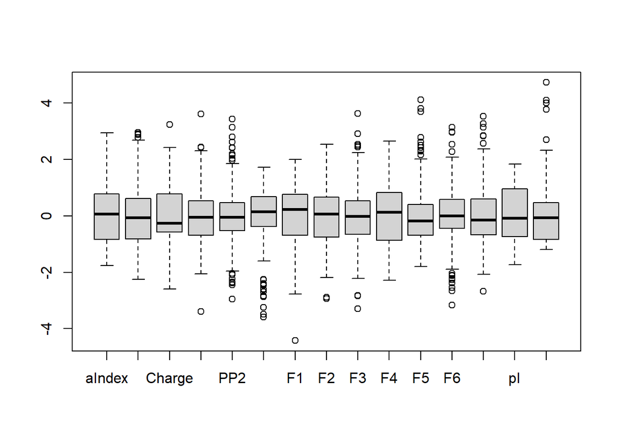

```r
boxplot(pepscale11)
```

## Calculo PCAs y obtención de archivo Excel de rotación

```r
PCApep11 = prcomp(pepscale11)
summary(PCApep11)
```

```
## Importance of components:
##                           PC1    PC2    PC3     PC4     PC5     PC6     PC7
## Standard deviation     2.2070 1.7925 1.4720 1.19042 0.91643 0.89131 0.74052
## Proportion of Variance 0.3247 0.2142 0.1445 0.09447 0.05599 0.05296 0.03656
## Cumulative Proportion  0.3247 0.5389 0.6834 0.77786 0.83385 0.88681 0.92337
##                            PC8     PC9    PC10    PC11   PC12    PC13    PC14
## Standard deviation     0.60790 0.55014 0.40570 0.34885 0.3075 0.23774 0.16674
## Proportion of Variance 0.02464 0.02018 0.01097 0.00811 0.0063 0.00377 0.00185
## Cumulative Proportion  0.94800 0.96818 0.97915 0.98727 0.9936 0.99734 0.99919
##                           PC15
## Standard deviation     0.11022
## Proportion of Variance 0.00081
## Cumulative Proportion  1.00000
```

```r
##write.csv2(PCApep11, "PCApep11.csv")##
```

## Para escoger el numero de PCAs

```r
stdev11= PCApep11$sdev
pr_var11 = stdev11^2
pr_var11[1:15]
```

```
##  [1] 4.87081721 3.21306632 2.16687801 1.41710464 0.83983776 0.79444020
##  [7] 0.54837012 0.36953871 0.30265136 0.16459211 0.12169369 0.09453973
## [13] 0.05651857 0.02780322 0.01214835
```

```r
prop_varex11 =pr_var11/sum(pr_var11)
prop_varex11[1:15]
```

```
##  [1] 0.3247211474 0.2142044215 0.1444585339 0.0944736428 0.0559891838
##  [6] 0.0529626800 0.0365580079 0.0246359140 0.0201767575 0.0109728071
## [11] 0.0081129124 0.0063026488 0.0037679044 0.0018535482 0.0008098902
```

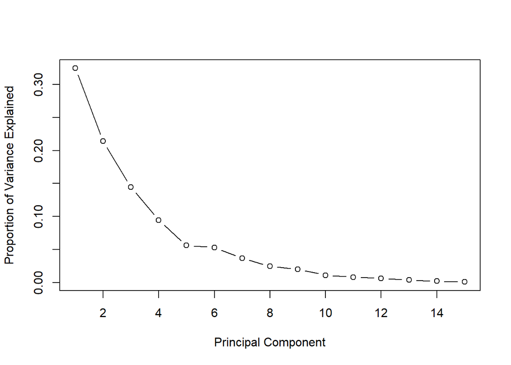

```r
plot(prop_varex11, xlab = "Principal Component",ylab = "Proportion of Variance Explained",type = "b")
```

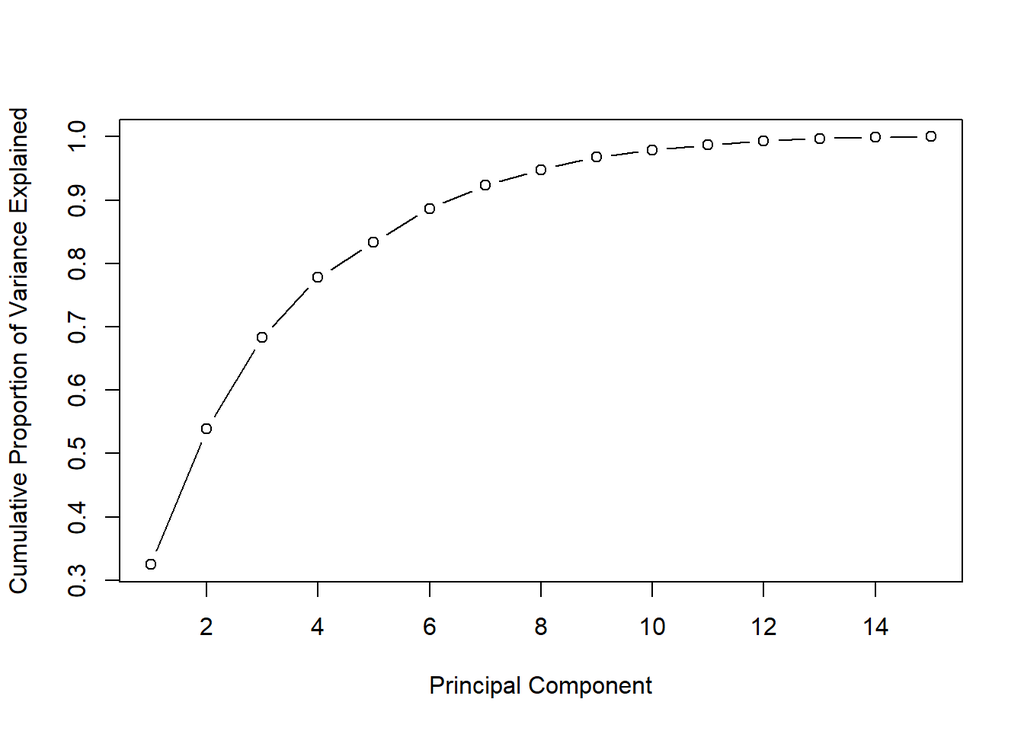

```r
plot(cumsum(prop_varex11), xlab = "Principal Component",ylab = "Cumulative Proportion of Variance Explained",type = "b")
```

## Determinar numero optimo de clusters por medio del metodo de “avarage silhouette”

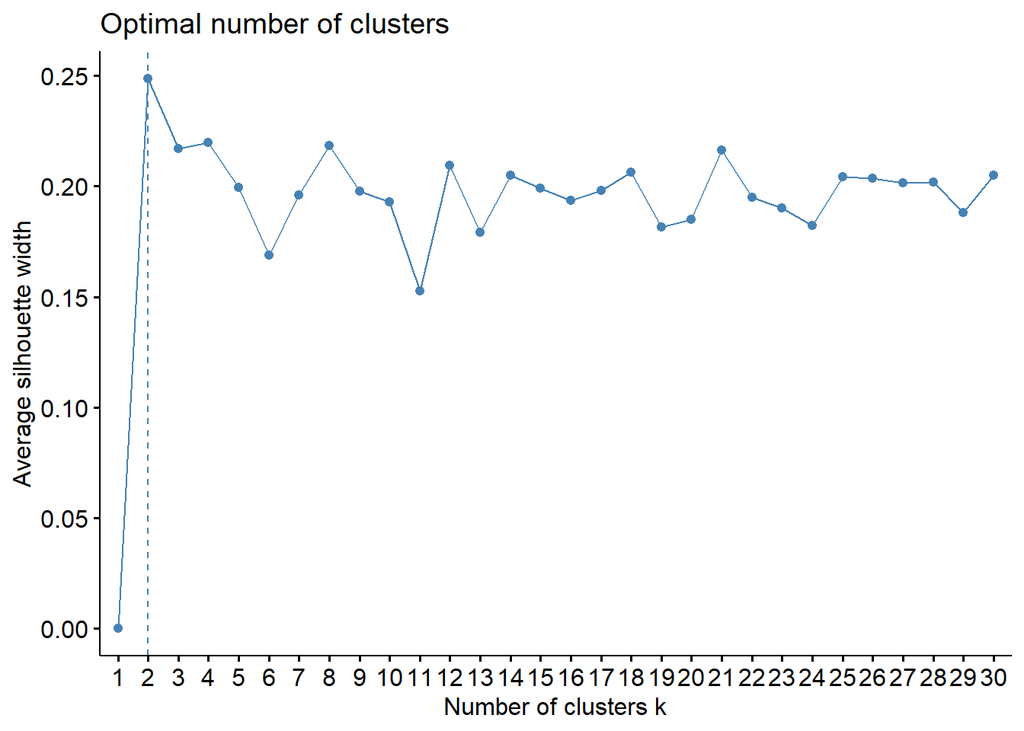

```r
fviz_nbclust(PCApep11$x[ ,1:15],kmeans,method = "silhouette", k.max = 30, iter.max=25)
```

## Graficar heatmap

## Heatmap de 11 clusters

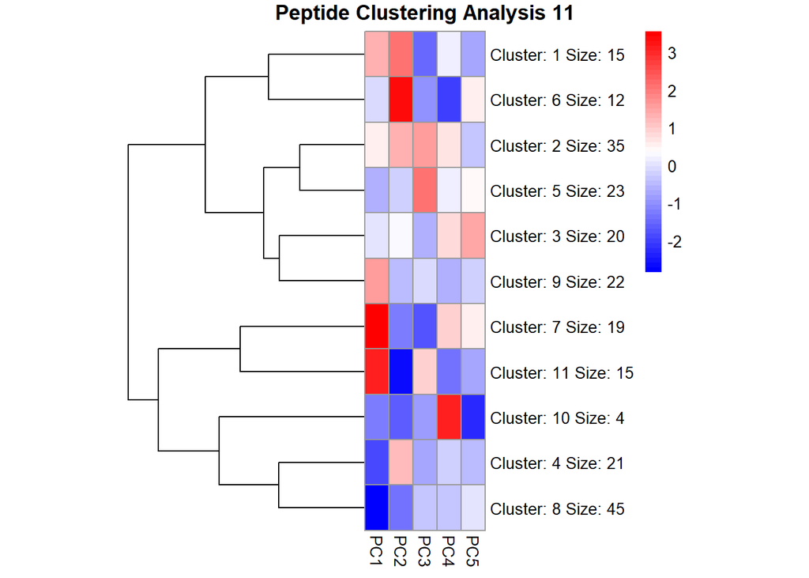

```r
cluster11pep= pheatmap(PCApep11$x[,1:5], kmeans_k = 11,cluster_cols = FALSE, treeheight_row = 150, cellwidth = 15, color = colorRampPalette(c("blue", "white", "red"))(50),main = "Peptide Clustering Analysis 11" )
```

```r
write.csv2 (cluster11pep$kmeans$cluster, file="clustermemberS11pep.csv")
```